# Lecture 16: Exploring multiple regression

**Learning Objectives**: See how coefficients, p-values, and predictions change when you add and remove variables from a multiple linear regression model.

**Instructions**: Submit written answers to the numbered questions on pencil and paper! This activity is Mini Quiz 6! You don’t need to write a lot in your handwritten answers, but I should be able to tell that you were making progress and learning something! You can work in groups!

# Getting Started

I made you three fake datasets to explore some properties of multiple regression. Download them with the following code:

```r
library(tidyverse)
dat.small <- read.csv("https://anna-neufeld.github.io/stat202_tutorials/Week9/dat.small.csv")
dat.big <- read.csv("https://anna-neufeld.github.io/stat202_tutorials/Week9/dat.big.csv")
dat.big.test <- read.csv("https://anna-neufeld.github.io/stat202_tutorials/Week9/dat.big.test.csv")
```

# 1. Starting with dat.small

This dataset has 30 observations, one response variable `y`, and $7$ predictor variables `x1`, `x2`, …, `x7`. The following code will show you relationships between all of your variables.

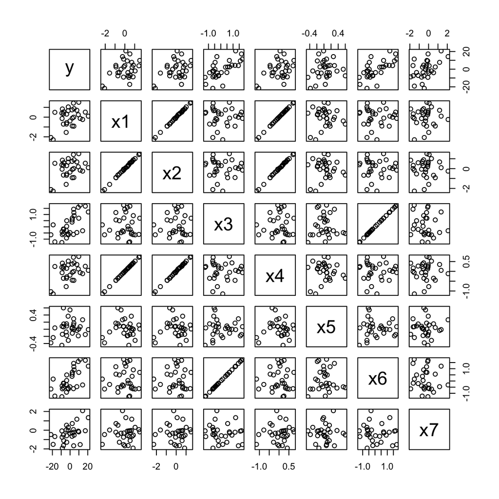

```r
pairs(dat.small)
```

The following code and output tells you about the pairwise correlations between all variables in your dataset.For example, 0.395 is the correlation between $y$ and $x2$ in this dataset. The values on the diagonal are all $1$, since every variable is perfectly correlated with itself!

```r
cor(dat.small)
```

|  | y | x1 | x2 | x3 | x4 | x5 | x6 | x7 |
| --- | --- | --- | --- | --- | --- | --- | --- | --- |
| y | 1.0000000 | 0.4037688 | 0.3953713 | 0.6584705 | 0.4037688 | 0.1849520 | 0.6589385 | 0.4923300 |
| x1 | 0.4037688 | 1.0000000 | 0.9994114 | 0.0000000 | 1.0000000 | 0.0153318 | 0.0011602 | 0.0578495 |
| x2 | 0.3953713 | 0.9994114 | 1.0000000 | -0.0041397 | 0.9994114 | 0.0308933 | -0.0029802 | 0.0471196 |
| x3 | 0.6584705 | 0.0000000 | -0.0041397 | 1.0000000 | 0.0000000 | 0.0009792 | 0.9999993 | -0.1126423 |
| x4 | 0.4037688 | 1.0000000 | 0.9994114 | 0.0000000 | 1.0000000 | 0.0153318 | 0.0011602 | 0.0578495 |
| x5 | 0.1849520 | 0.0153318 | 0.0308933 | 0.0009792 | 0.0153318 | 1.0000000 | 0.0009970 | 0.0266500 |
| x6 | 0.6589385 | 0.0011602 | -0.0029802 | 0.9999993 | 0.0011602 | 0.0009970 | 1.0000000 | -0.1125751 |
| x7 | 0.4923300 | 0.0578495 | 0.0471196 | -0.1126423 | 0.0578495 | 0.0266500 | -0.1125751 | 1.0000000 |

We will now try out a bunch of regressions of `y` on subsets of the predictor variables `x1`,…,`x7`. For each exercise, try out some code in your console, and then record a handwritten answer on your mini quiz.

1. Highly correlated predictors: Compare a linear regression of `y` on `x1` to a linear regression of `y` on `x1` and `x2`. Specifically, compare your two models in terms of: the coefficient for `x1`, its standard error, its p-value, and $R^2$. What did you learn from this problem?
2. Perfectly uncorrelated predictors:** Compare a linear regression of `y` on `x1` to a linear regression of `y` on `x1` and `x3`. What do you notice about: the coefficient on `x1`, its standard error, its p-value, and $R^2$? What did you learn from this problem?
3. Perfectly correlated predictors:** What happens if you fit a linear regression of `y` on `x1` and `x4`? What do you learn from this?
4. Mostly uncorrelated predictors:** What happens if you fit a linear regression of `y` on `x1` and `x5` and `x6` and `x7`. How does this model compare to ones from the previous parts? Play around with this model by adding or removing one variable at a time, and be sure to check out the correlations between different pairs of these variables. What did you learn from this, and how does it relate to the previous parts of the question?
5. What would be your pick for a “final model” for this dataset?** Be sure that you can justify your answer!

# 2. Moving on to dat.big

The dataset `dat.big` that you downloaded above has 30 observations and 29 variables. The following command will let you fit a regression of `y` on all other variables in the dataset.

```r
mod.full <- lm(y~., data=dat.big)
```

Check the $R^2$ of this model. While you are at it, compare your predicted values (stored in `mod.full$fitted`) to the actual values of $y$ in your dataset. What is going on in this dataset?

Do some visualizing and exploring of your data. Consider some smaller models that have fewer than 29 variables in them.

6. Based on your exploration, do you think that the best model is the one with the highest $R^2$? Why or why not?

# 3. Evaluating a model using an independent test set

The dataset `test.big` comes from exactly the same population as `dat.big`. In this question, we will see that the giant `mod.full` from Question 2 does a very bad job making predictions for unseen examples, despite the fact that its predictions were perfect on its own dataset. This phenomenon is known as *overfitting*: `mod.full` was so complex that it perfectly traced the training dataset values, but cannot generalize to unseen examples. This is an example of why we cannot directly trust $R^2$ as a measure of model performance.

Run the following code, which computes the SSE of this “full model” when it is applied to the test set.

```r
preds.test <- predict(mod.full, newdata=dat.big.test)
sum((preds.test - dat.big.test$y)^2)
```

Compare this SSE to a much simpler model, which only uses `x1` and `x5` for predictions. What do you notice?

```r
mod.small <- lm(y~x1+x5, data=dat.big)
preds.test.small <- predict(mod.small, newdata=dat.big.test)
sum((preds.test.small - dat.big.test$y)^2)
```

It is not, however, the case that the simplest model is always the best. We can see this by considering the intercept-only model, which is worse than the model above.

```r
mod.intercept <- lm(y~1, data=dat.big)
preds.intercept <- predict(mod.intercept, newdata=dat.big.test)
sum((preds.intercept- dat.big.test$y)^2)
```

3. Based on the past few explorations, as well as what you explored in Question 2, what do you think is the “best model” for this dataset?

This is the last question of the mini quiz! Move on to the next part, but only if you have time!

# Totally optional code to explore if you have time.

I wrote you the following code. It considers the regression of $y$ on $x_1,\ldots,x_k$, for $k$ ranging from $0$ (the intercept only model) to $29$ (the full model). It fits each regression model to `dat.big,` but then considers the sum of squared errors both on its own training data (`dat.big`) and the unseen test data (`dat.big.test`). The code is below.

```r
SSE.train <- rep(0, 30)
SSE.test <- rep(0,30)

mod.train <- lm(y~1, data=dat.big)
SSE.train[1] <- sum((mod.train$fitted-dat.big$y)^2)
preds.test <- predict(mod.train, newdata=dat.big.test)
SSE.test[1] <- sum((preds.test -dat.big$y)^2)
for (k in 2:30) {
  mod.train <- lm(y~., data=dat.big[,1:k])
  SSE.train[k] <- sum((mod.train$fitted-dat.big$y)^2)
  preds.test <- predict(mod.train, newdata=dat.big.test)
  SSE.test[k] <- sum((preds.test -dat.big.test$y)^2)
}
```

To make these numbers more interpretable, we convert them from SSE values to $R^2$ values. Recall that
$$R^2 = 1 - SSE/SST.$$

```r
R2.train <- 1-SSE.train/(sum((dat.big$y-mean(dat.big$y))^2))
R2.test <- 1-SSE.test/(sum((dat.big.test$y-mean(dat.big.test$y))^2))
```

The following plot shows how $R^2$, computed using the training set and the test set, change as we add more variables to the model. What do you notice? How does this knowledge coincide with your knowledge about the best possible model for this data? To the best of your ability, explain what is going on in this plot!

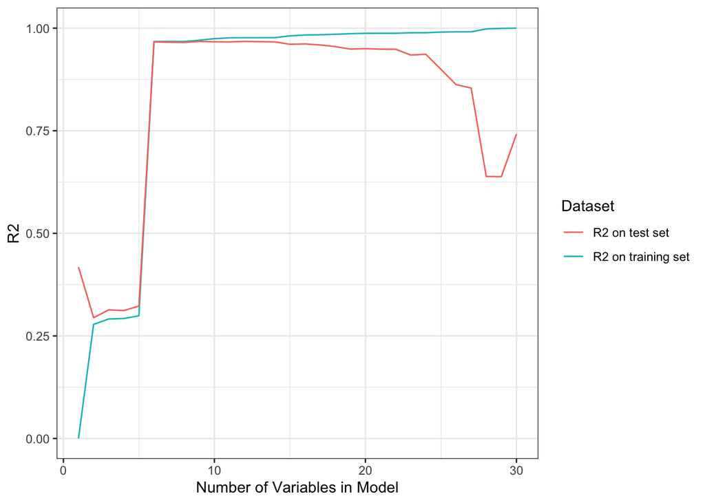

```r
ggplot(data=NULL) +
  geom_line(aes(x=1:30, y=R2.train, col="R2 on training set"))+
  geom_line(aes(x=1:30, y=R2.test, col="R2 on test set")) +
  theme_bw()+ylab("R2")+labs(col="Dataset")+
  xlab("Number of Variables in Model")
```

# Takeaways (not as optional)

I hope you learned that:

- Multiple regression is tricky in the presence of correlated predictors.
  - When the correlation between two predictors is 1, the model can literally not be fit (the design matrix is singular)!
  - When the correlation between two predictors is quite high, the model is *unstable*. This also has to do with near-singularity (tiny eigenvalues in the design matrix).
  - When the correlation between two predictors is actually 0, adding the second variable to the model does not change the coefficient on the first!
  - When the correlation between two predictors is small but non-zero, adding a new variable to the model always changes the coefficient on the first, but it might only change it slightly.
- Measures like $R^2$, computed using the same dataset that was used to fit the model, will always increase when you increase the number of predictors. so just looking at an increasing $R^2$ is not a good way to say that a more complex model is “better”.
- A test set is a better way to assess the ability of a model to generate accurate predictions for a *new sample*.

We will return to some of these topics next week when we study model selection!

## Acknowledgements

The formatting of this tutorial was adopted from an OpenIntro lab.

This is a product of OpenIntro that is released under a [Creative Commons Attribution-ShareAlike 3.0 Unported](http://creativecommons.org/licenses/by-sa/3.0).